# 1. Molare Entropie

Berechnen Sie die molare Entropie von ClO$_2$ bei Raumtemperatur. Die Bindungslänge einer ClO-Bindung im ClO$_2$-Molekül beträgt 149 pm. Der O–Cl–O-Winkel ist 118.5°. Das Molekül besitzt die Punktgruppe C$_{2v}$ und einen zweifach entarteten elektronischen Grundzustand. Nehmen Sie für die Berechnung an, dass Sie bei der betrachteten Temperatur den Beitrag der Schwingungen sowie den der elektronisch angeregten Zustände vernachlässigen können. Behandeln Sie ClO$_2$ zudem als starren Rotator.

Annahmen:

Die Sackur-Tetrode-Gleichung beschreib die Entropy eines monoatomaren Gases und ist eine gute Näherung für die Translationsentropie:

$$ S_{\text {trans }}=R \ln \left(\left(\frac{2 \pi m k T}{h^{2}}\right)^{3 / 2} \frac{e^{5 / 2} V}{N_A}\right) $$

- $R$ ist die molare Gaskonstante
- $e$ ist die Euler'sche Zahl
- $V$ ist das molare Volumen 22.465 l/mol

```python
import numpy as np
from scipy.constants import R, k, h, N_A
from math import pi

T = 298
V = 22.465 * 1e-3 # m^3 / mol
m = (35.453 + 15.999 * 2) * 1e-3 # kg/mol
S_trans = R * np.log( (2 * pi * (m/N_A) * k * T / h**2)**(3/2) * np.exp(5/2) * V / N_A )

print(f"Die molare Translationsentropy ist {S_trans:.3f} J/(mol * K).")
```

```
Die molare Translationsentropy ist 160.554 J/(mol * K).
```

Für die molare Rotationsentropy gilt folgender Zusammenhang:

$$ S_{\text {rot }}=R \ln \left(\sqrt{\frac{\pi T^{3}}{\theta_{x} \theta_{y} \theta_{z}}} \frac{e^{3 / 2}}{\sigma}\right) $$

Mit der Symmetryzahl $\sigma$ folgend aus der Drehzähligkeit. Hierbei sind $\theta_{i}$ charakteristische Rotationstemperaturen, die sich anhand der Trägheitskomponenten berechnen lassen: $$ \theta_{i}=\frac{h^{2}}{8 \pi^{2} I_{i} k} $$

Mit dem Trägheitsmoment: $$ I_i = \sum_i m_i r_i^2 $$

Gegeben war der Cl-O Bindungsabstand von $r=149~pm$ und der Bindungswinkel von $118.5 °$. Daraus lassen sich die Koordinaten bestimmen, wobei wir Cl in den Ursprung legen.

```python
import numpy as np
from numpy import sin, cos
from scipy.constants import pico
from ase.atoms import Atoms
from ase.visualize import view

# first we calculate the coordinates
theta = 118.5 / 180 * np.pi
r_O1 = np.array([149, 0, 0]) * pico
R_z = np.array([[cos(theta), -sin(theta), 0],
                [sin(theta),  cos(theta), 0],
                [         0,           0, 1]])
r_O2 = np.dot(R_z, r_O1)
r_Cl = np.array([0,0,0])
positions = np.array([r_Cl, r_O1, r_O2])
symbols = ["Cl", "O", "O"]
for s, p in zip(symbols, positions):
    print(s, "{:.3e} {:.3e} {:.3e}".format(*p))
```

```
Cl 0.000e+00 0.000e+00 0.000e+00
O 1.490e-10 0.000e+00 0.000e+00
O -7.110e-11 1.309e-10 0.000e+00
```

```python
# then we setup the calculation of the intertial moment
m_O = 15.99999 * 1e-3 / N_A
m_Cl = 35.453 * 1e-3 / N_A
masses = [m_Cl, m_O, m_O]
symbols = ["Cl", "O", "O"]
center_of_mass = 1/(2* m_O + m_Cl) * (m_Cl * r_Cl + m_O * r_O1 + m_O * r_O2 )
relative_positions = positions - center_of_mass

# Initialize elements of the inertial tensor
I11 = I22 = I33 = I12 = I13 = I23 = 0.0
for i in range(3):
    x, y, z = relative_positions[i]
    m = masses[i]

    I11 += m * (y ** 2 + z ** 2)
    I22 += m * (x ** 2 + z ** 2)
    I33 += m * (x ** 2 + y ** 2)
    I12 += -m * x * y
    I13 += -m * x * z
    I23 += -m * y * z

I = np.array([[I11, I12, I13],
              [I12, I22, I23],
              [I13, I23, I33]])
```

```python
# obtain the eigenvalues and eigenvectors of the inertial tensor
evals, evecs = np.linalg.eigh(I)

print(f"""Die Komponenten des Trägheitsmoments sind
I_x={evals[0]:.2e}
I_y={evals[1]:.2e}
I_z={evals[2]:.2e} kg m^2.""")

theta = h**2 / (8 * np.pi**2 * evals * k)

print(f"""Daraus ergeben sich die charakteristischen Rotationstemperaturen
theta_x={theta[0]:.2f} K
theta_y={theta[1]:.2f} K
theta_z={theta[2]:.2f} K.""")

S_rot = R * np.log( np.sqrt((np.pi * T**3)/(theta[0]*theta[1]*theta[2])) * np.exp(3/2)/2)
print(f"Man erhält eine Rotationsentropy von {S_rot:.4f} J/(mol * K).")
```

```
Die Komponenten des Trägheitsmoments sind
I_x=1.62e-46
I_y=8.71e-46
I_z=1.03e-45 kg m^2.
Daraus ergeben sich die charakteristischen Rotationstemperaturen
theta_x=2.48 K
theta_y=0.46 K
theta_z=0.39 K.
Man erhält eine Rotationsentropy von 85.8614 J/(mol * K).
```

Für die elektronische Entropie des Grundzustands gilt ein einfacher Zusammenhang:

$$ S_{el} = R \cdot \ln(g_0) $$

Wobei $g_0$ der Entartungsgrad des Grundzustands ist.

```python
S_el = R * np.log(2)
print(f"Man erhält eine elektronische Entropie von {S_el:.4f} J/(mol * K).")

S_tot = S_trans + S_rot + S_el
print(f"Die Gesamtentropie beträgt {S_tot:.4f} J/(mol*K).")
```

```
Man erhält eine elektronische Entropie von 5.7631 J/(mol * K).
Die Gesamtentropie beträgt 252.1782 J/(mol*K).
```

# 2. Molekulare Wärmekapazität

CO2 (Bindungsabstand 116,3 pm) liegt in einen Singulett-Grundzustand vor. Es besitzt eine symmetrische Streckschwingung vom Typ $\Sigma_g^+$ mit einer Wellenzahl von $\tilde{\nu}= 1340$ cm$^{−1}$, eine asymmetrische Streckschwingung vom Typ $\Sigma_u^+$ mit einer Wellenzahl von $\tilde{\nu}= 2349$ cm$^{−1}$ und eine entartete Knickschwingung vom Typ $\Pi_u$ mit einer Wellenzahl von $\tilde{\nu}= 667$ cm$^{−1}$.

a) Berechnen und zeichnen Sie die molare isochore Wärmekapazität $C_{\bar{V}}$ (bei Standarddruck) als Funktion der Temperatur im Bereich von 0 K bis 1200 K. Verwenden Sie die harmonische Näherung, vernachlässigen Sie elektronische Anregungen und nehmen Sie an, CO$_2$ verhalte sich wie ein starrer Rotator.

$$ c_{\bar{V}} = c_{\bar{V}}^{trans} + c_{\bar{V}}^{rot} + c_{\bar{V}}^{vib} $$

Die Translations- und Rotationszustände sind quasi alle angeregt (charakteristische Rotationstemperatur von $1.76~K$) und ergeben insgesamt einen Beitrag von $2.5~R$ zur Wärmekapazität.

Der Beitrag der Schwingungen lässt sich wie folgt berechnen:

$$ c_{\bar{V}, m}^{vib}= R \cdot \left(\frac{\theta_{vib}}{T}\right)^{2}\left(\frac{e^{-\frac{\theta_{vib}}{2 T}}}{1-e^{-\frac{\theta_{vib}}{T}}}\right)^{2} $$

Wobei die charakteristischen Schwingungstemperaturen wie folgt berechnet werden:

$$ \theta_{vib}=\frac{h c \tilde{v}}{k} $$

Die Knickschwingung ist dabei zweifach entartet.

```python
from scipy.constants import h, c, R, k
from numpy import exp, pi

temperatures = np.linspace(1,1200,100)
nu_1 = 1340 * 1e2 # m
nu_2 = 2349 * 1e2 # m
nu_3 = 667 * 1e2 # m, zweifach entartet

theta_vib_1 = h * c * nu_1 / k
theta_vib_2 = h * c * nu_2 / k
theta_vib_3 = h * c * nu_3 / k
print(f"Die charakteristischen Schwingungstemperaturen sind {theta_vib_1:.2f} K, {theta_vib_2:.2f} K und {theta_vib_3:.2f} K.")
```

```
Die charakteristischen Schwingungstemperaturen sind 1927.96 K, 3379.69 K und 959.66 K.
```

```python
def c_vib(theta_vib, T):
    c = R * (theta_vib / T)**2
    c *= (exp(-theta_vib/(2*T)) / (1 - exp(-theta_vib / T)) )**2
    return c

c_tots = []
for T in temperatures:
    c_1 = c_vib(theta_vib_1, T)
    c_2 = c_vib(theta_vib_2, T)
    c_3 = 2 * c_vib(theta_vib_3, T) # doubly degenerate
    c_tot = 2.5 * R + c_1 + c_2 + c_3
    c_tots.append(c_tot)
```

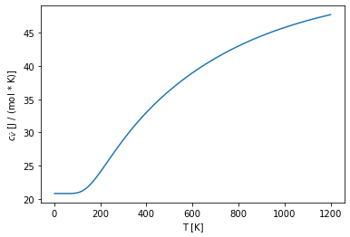

```python
import matplotlib.pyplot as plt
plt.plot(temperatures, c_tots)
plt.ylabel(r"$c_{\bar{V}}$ [J / (mol * K)]")
plt.xlabel("T [K]")
```

b) Kennzeichnen Sie die Temperaturbereiche, in denen die von Ihnen berechnete Wärmekapazität Gültigkeit besitzt.

Unter 200 K ist CO$_2$ nicht mehr gasförmig, sondern gefriert, sodass die Annahmen nicht mehr zutreffen. Bei höheren Temperaturen kommt es zur Anregung elektronischer Freiheitsgrade oder sogar zur Dissoziation (~1000 K).

c) Vergleichen Sie das in (a) erhaltene Ergebnis mit möglichst vielen verschiedenen Literaturwerten. Beachten Sie dabei die Herkunft der Literaturwerte (aus kalorimetrischen Messungen, spektroskopischen Bestimmungen etc.)

| Temperatur | Berechnet | Lange's Handbook of Chemistry, 10th ed, pp 1525-1528 | http://webbook.nist.gov/cgi |
| --- | --- | --- | --- |
| 200 K | 24.05 | 24.74 | 22.87 |
| 270 K | 27.49 | 27.73 | 27.27 |
| 290 K | 28.44 | 28.08 | 28.17 |
| 370 K | 31.87 | 29.67 | 31.39 |
| 670 K | 40.57 | 35.47 | 39.62 |

# 3. Debye- und Einstein-Model

Für Blei beträgt die Grenzfrequenz $\nu_{max} = 0.19 \cdot 10^{13}~s^{−1}$. Berechnen Sie mit dieser Information die molare isochore Wärmekapazität von Blei im Rahmen der Modelle von Einstein und Debye für 20 K und 40 K. Vergleichen Sie die erhaltenen Werte mit experimentellen Daten.

$$ \begin{aligned} T_1 &= 20~K \\ T_2 &= 40~K \\ v_{max} &= 0.19 \cdot 10^{13}~s^{−1} \\ c_{\bar{V}}(20~K, exp.) &= 11.01~J/(K \cdot mol)\\ c_{\bar{V}}(40~K, exp.) &= 19.57~J/(K \cdot mol)\\ \end{aligned} $$

## Einstein-Model

$$ C_{V}=3 R\left(\frac{\Theta_{\mathrm{E}}}{T}\right)^{2} \frac{e^{\Theta_{\mathrm{E}} / T}}{\left(e^{\Theta_{\mathrm{E}} / T}-1\right)^{2}} \text { mit } \frac{\Theta_{\mathrm{E}}}{T}=\frac{h v_{\max }}{k T} $$

Hierbei ist $v_{\max}$ die Grenzfrequenz.

```python
v_max = 0.19 * 1e13
T_1 = 20
T_2 = 40

Omega = h * v_max / k

C_V1 = 3 * R * (Omega/T_1)**2 * exp(Omega/T_1) / (exp(Omega/T_1) - 1)**2
C_V2 = 3 * R * (Omega/T_2)**2 * exp(Omega/T_2) / (exp(Omega/T_2) - 1)**2
print("""Die isochore molare Wärmekapazität nach Einstein beträgt
{:.4f} J/(K * mol) bei 20 K und
{:.4f} J/(K * mol) bei 40 K.
""".format(C_V1, C_V2)
)
```

```
Die isochore molare Wärmekapazität nach Einstein beträgt
5.5439 J/(K * mol) bei 20 K und
16.4593 J/(K * mol) bei 40 K.
```

## Debye-Model

$$ C_{V}=9 R\left(\frac{T}{\Theta_{\mathrm{D}}}\right)^{3} \int_{0}^{\Theta_{\mathrm{D}} / T} \frac{x^{4} e^{x}}{\left(e^{x}-1\right)^{2}} \mathrm{~d} x \text { mit } \frac{\Theta_{\mathrm{D}}}{T}=\frac{h v_{\max }}{k T} \text { und } x=\frac{h v}{k T} $$

```python
from scipy.integrate import trapz

Omega = h * v_max / k

def debye_heat_capacity(T):
    x = np.linspace(1e-3, h * v_max / (k*T), 1000)
    y = x**4 * exp(x) / (exp(x) - 1)**2
    c_V = 9 * R * (T / Omega)**3 * trapz(y, x)
    return (c_V, x, y)

c1, x1, y1, = debye_heat_capacity(T_1)
c2, x2, y2 = debye_heat_capacity(T_2)
print("""Die isochrome molare Wärmekapazität nach Debye beträgt
{:.4f} J/(K * mol) bei 20 K und
{:.4f} J/(K * mol) bei 40 K.
""".format(c1, c2)
)
```

```
Die isochrome molare Wärmekapazität nach Debye beträgt
10.5779 J/(K * mol) bei 20 K und
19.4972 J/(K * mol) bei 40 K.
```

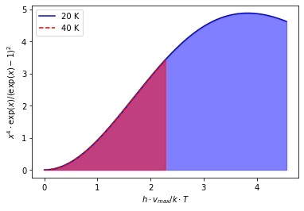

```python
plt.plot(x1, y1, color="blue", label="20 K")
plt.fill_between(x1, 0, y1, color="blue", alpha=0.5)
plt.plot(x2, y2, color="red", label="40 K", ls="--")
plt.fill_between(x2, 0, y2, color="red", alpha=0.5)
plt.xlabel(r"$h \cdot v_{max} / k \cdot T$")
plt.ylabel(r"$x^4 \cdot \exp(x) / (\exp(x) - 1)^2$")

plt.legend()
```

Berechnen Sie die molare isochore Wärmekapazität von Diamant bei $T=300~K$ im Rahmen des Einstein-Modells. Schätzen Sie hierfür die charakteristische Frequenz aus der typischen Wellenzahl von C-C-Einfachbindungen (aus der IR- Spektroskopie) ab. Vergleichen Sie den erhaltenen Wert mit experimentellen Daten ($5.6~J~K^{−1}~mol^{−1}$).

Die IR-Wellenzahl für die CC-Einfachbindung liegt bei ungefähr $\tilde{\nu}= 1000$ cm$^{−1}$ (800 bis 1200 cm$^{−1}$). Daraus folgt eine Frequenz von $\nu = c \cdot \tilde{\nu} = 3 \cdot 10^{13}$ s$^{−1}$ ($2.4 − 3.6 \cdot 10^{13}$ s$^{−1}$).

```python
v_max1 = 2.4 * 1e13
v_max2 = 3.6 * 1e13
T = 300

Omega1 = h * v_max1 / k
Omega2 = h * v_max2 / k

C_V1 = 3 * R * (Omega1/T)**2 * exp(Omega1/T) / (exp(Omega1/T) - 1)**2
C_V2 = 3 * R * (Omega2/T)**2 * exp(Omega2/T) / (exp(Omega2/T) - 1)**2
print("""Die isochrome molare Wärmekapazität nach Einstein beträgt
{:.4f} - {:.4f} J/(K * mol) bei 300 K.
""".format(C_V1, C_V2)
)
```

```
Die isochrome molare Wärmekapazität nach Einstein beträgt
8.2592 - 2.6258 J/(K * mol) bei 300 K.
```